# Pratical Machine Learning - Prediction Assignment Writeup

rlfacanha

08/09/2020

## Overview

People regularly quantify how much of a particular activity they do, but they rarely quantify how well they do it.

The goal of this project is to predict the manner in which a group of people exercise.

The data will come from accelerometers on the belt, forearm, arm, and dumbell of 6 participants. The individuals performed barbell lifts correctly and incorrectly in 5 different ways: exactly according to the specification (Class A), throwing the elbows to the front (Class B), lifting the dumbbell only halfway (Class C), lowering the dumbbell only halfway (Class D) and throwing the hips to the front (Class E).

Class A corresponds to the specified execution of the exercise, while the other 4 classes correspond to common mistakes.

Read more: http:/groupware.les.inf.puc-rio.br/har#ixzz4TjqNZMWx

More information is available from the website here: http://web.archive.org/web/20161224072740/http:/groupware.les.inf.puc-rio.br/har (section Weight Lifting Exercise Dataset)

### Loading Data

The training data for this project are available at:

https://d396qusza40orc.cloudfront.net/predmachlearn/pml-training.csv

The test data are available at:

https://d396qusza40orc.cloudfront.net/predmachlearn/pml-testing.csv

```r
library(caret)
library(e1071)
library(data.table)
library(dplyr)
```

```r
library(ggplot2)
library(rattle)
library(gbm)
pml_training_url <-"https://d396qusza40orc.cloudfront.net/predmachlearn/pml-training.csv"
pml_testing_url <- "https://d396qusza40orc.cloudfront.net/predmachlearn/pml-testing.csv"
pml_training <- read.table("pml-training.csv", sep =",", header = TRUE )
pml_testing <- read.table("pml-testing.csv", sep =",", header = TRUE )
dim(pml_training)
```

```
## [1] 19622   160
```

```r
dim(pml_testing)
```

```
## [1]  20 160
```

```r
#check variable "classe"
table(pml_training$classe)
```

```
##
##    A    B    C    D    E
## 5580 3797 3422 3216 3607
```

Before modeling, predictor data will be pre-processed.

```r
#Remove near zero covariates
nsv <- nearZeroVar(pml_training,saveMetrics=TRUE)
training <- pml_training[,!nsv$nzv]
testing <- pml_testing[,!nsv$nzv]
#Removing variables with missing values
training <- training[,(colSums(is.na(training)) == 0)]
testing <- testing[,(colSums(is.na(testing)) == 0)]
#Removing unnused columns
training <- training[,-c(1:6)]
testing <- testing[,-c(1:6)]
# factorize variables
fcts <- c("classe")
training[fcts] <- lapply(training[fcts], factor)
```

### Testing Different Approaches for Prediction Models

In order to build a prediction model, the variable “classe” in the training set will be used and data will be splited into training and testing datasets at each new approach.

First approach will use prediction with trees.

```r
#Partition the training data into a training set and a #testing/validation set
inTrain <- createDataPartition(y=training$classe, p=0.7, list=FALSE)
training_partition <- training[inTrain,]
testing_partition <- training[-inTrain,]
dim(training_partition)
```

```
## [1] 13737    53
```

```r
dim(testing_partition)
```

```
## [1] 5885   53
```

```r
set.seed(125)
#Training resampling with method repeated cross validation
controlTree <- trainControl(method="cv", number=5)
modTree <- train(classe ~., method="rpart", data=training_partition, trControl=controlTree)
print(modTree$finalModel)
```

```
## n= 13737
##
## node), split, n, loss, yval, (yprob)
##       * denotes terminal node
##
##  1) root 13737 9831 A (0.28 0.19 0.17 0.16 0.18)
##    2) roll_belt< 129.5 12499 8637 A (0.31 0.21 0.19 0.18 0.11)
##      4) pitch_forearm< -33.15 1137   13 A (0.99 0.011 0 0 0) *
##      5) pitch_forearm>=-33.15 11362 8624 A (0.24 0.23 0.21 0.2 0.12)
##       10) magnet_dumbbell_y< 426.5 9441 6785 A (0.28 0.18 0.24 0.19 0.1)
##         20) roll_forearm< 123.5 5902 3509 A (0.41 0.18 0.19 0.17 0.057) *
##         21) roll_forearm>=123.5 3539 2346 C (0.074 0.17 0.34 0.23 0.18) *
##       11) magnet_dumbbell_y>=426.5 1921  944 B (0.043 0.51 0.046 0.22 0.18) *
##    3) roll_belt>=129.5 1238   44 E (0.036 0 0 0 0.96) *
```

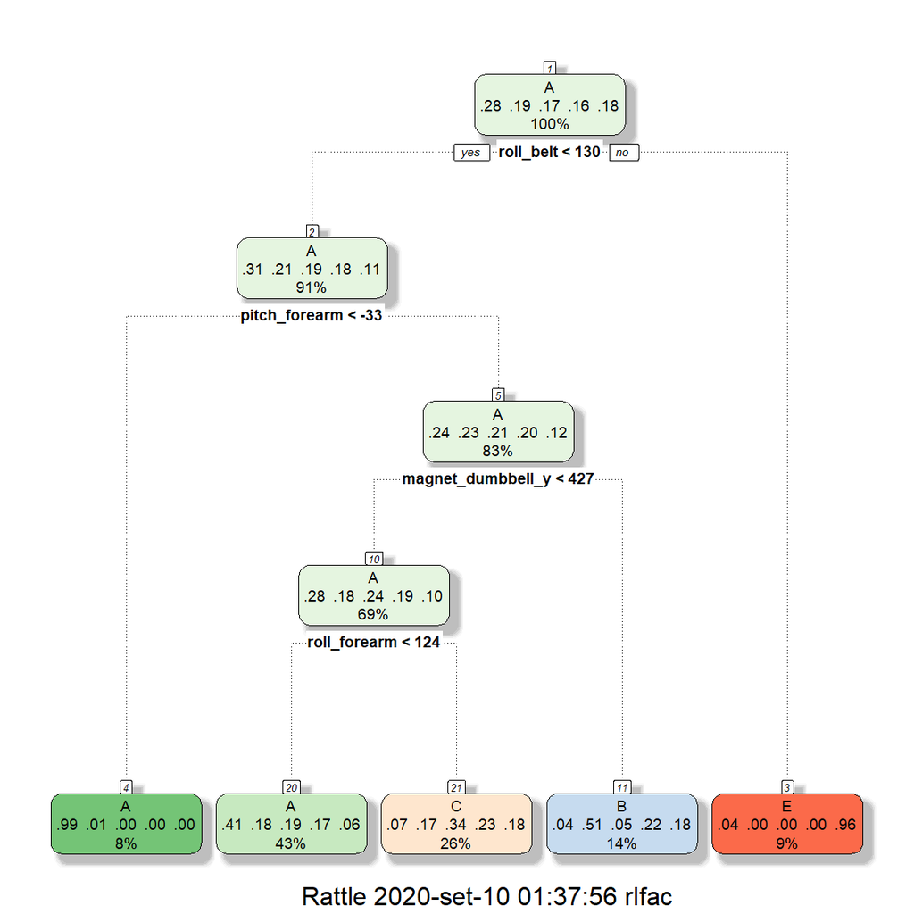

```r
fancyRpartPlot(modTree$finalModel)
```

```r
#Predicting new values
predmodTree <- predict(modTree,newdata=testing_partition)
##Accuracy
confMatTree <- confusionMatrix(predict(modTree,newdata=testing_partition), testing_partition$classe)
confMatTree
```

```
## Confusion Matrix and Statistics
##
##           Reference
## Prediction    A    B    C    D    E
##          A 1475  475  455  423  145
##          B   40  371   40  188  148
##          C  129  293  531  353  284
##          D    0    0    0    0    0
##          E   30    0    0    0  505
##
## Overall Statistics
##
##                Accuracy : 0.4897
##                  95% CI : (0.4769, 0.5026)
##     No Information Rate : 0.2845
##     P-Value [Acc > NIR] : < 2.2e-16
##
##                   Kappa : 0.3344
##
##  Mcnemar's Test P-Value : NA
##
## Statistics by Class:
##
##                      Class: A Class: B Class: C Class: D Class: E
## Sensitivity            0.8811  0.32572  0.51754   0.0000  0.46673
## Specificity            0.6443  0.91235  0.78205   1.0000  0.99375
## Pos Pred Value         0.4961  0.47141  0.33396      NaN  0.94393
## Neg Pred Value         0.9317  0.84935  0.88475   0.8362  0.89215
## Prevalence             0.2845  0.19354  0.17434   0.1638  0.18386
## Detection Rate         0.2506  0.06304  0.09023   0.0000  0.08581
## Detection Prevalence   0.5052  0.13373  0.27018   0.0000  0.09091
## Balanced Accuracy      0.7627  0.61904  0.64980   0.5000  0.73024
```

Prediction with trees has low accuracy; so out of sample error is too high.

Second approach will use random forest. Cross validation in training set is done with cross validation method.

```r
#Partition the training data into a training set and a #testing/validation set
inTrain <- createDataPartition(y=training$classe, p=0.7, list=FALSE)
training_partition <- training[inTrain,]
testing_partition <- training[-inTrain,]
dim(training_partition)
```

```
## [1] 13737    53
```

```r
dim(testing_partition)
```

```
## [1] 5885   53
```

```r
set.seed(123)
#Training resampling with method repeated cross validation
controlRF <- trainControl(method="cv", number=3)
modClasseRF <- train(classe ~., method="rf",data=training_partition, trControl=controlRF)
print(modClasseRF$finalModel)
```

```
##
## Call:
##  randomForest(x = x, y = y, mtry = param$mtry)
##                Type of random forest: classification
##                      Number of trees: 500
## No. of variables tried at each split: 27
##
##         OOB estimate of  error rate: 0.75%
## Confusion matrix:
##      A    B    C    D    E class.error
## A 3902    1    1    0    2 0.001024066
## B   21 2627    9    1    0 0.011662904
## C    0   14 2371   11    0 0.010434057
## D    1    2   24 2223    2 0.012877442
## E    0    2    5    7 2511 0.005544554
```

```r
#Predicting new values
predmodRF <- predict(modClasseRF,newdata=testing_partition)
#Accuracy
confMatRF <- confusionMatrix(predict(modClasseRF, testing_partition), testing_partition$classe)
confMatRF
```

```
## Confusion Matrix and Statistics
##
##           Reference
## Prediction    A    B    C    D    E
##          A 1673    3    0    0    0
##          B    1 1135    9    0    1
##          C    0    1 1014   11    5
##          D    0    0    3  953    5
##          E    0    0    0    0 1071
##
## Overall Statistics
##
##                Accuracy : 0.9934
##                  95% CI : (0.991, 0.9953)
##     No Information Rate : 0.2845
##     P-Value [Acc > NIR] : < 2.2e-16
##
##                   Kappa : 0.9916
##
##  Mcnemar's Test P-Value : NA
##
## Statistics by Class:
##
##                      Class: A Class: B Class: C Class: D Class: E
## Sensitivity            0.9994   0.9965   0.9883   0.9886   0.9898
## Specificity            0.9993   0.9977   0.9965   0.9984   1.0000
## Pos Pred Value         0.9982   0.9904   0.9835   0.9917   1.0000
## Neg Pred Value         0.9998   0.9992   0.9975   0.9978   0.9977
## Prevalence             0.2845   0.1935   0.1743   0.1638   0.1839
## Detection Rate         0.2843   0.1929   0.1723   0.1619   0.1820
## Detection Prevalence   0.2848   0.1947   0.1752   0.1633   0.1820
## Balanced Accuracy      0.9993   0.9971   0.9924   0.9935   0.9949
```

Random forest has very high accuracy; so out of sample error is very low.

Third approach will use boosting with trees. Cross validation in training set is done with repeated cross validation method.

```r
#Partition the training data into a training set and a #testing/validation set
inTrain <- createDataPartition(y=training$classe, p=0.7, list=FALSE)
training_partition <- training[inTrain,]
testing_partition <- training[-inTrain,]
dim(training_partition)
```

```
## [1] 13737    53
```

```r
dim(testing_partition)
```

```
## [1] 5885   53
```

```r
set.seed(999)
#Training resampling with method repeated cross validation
controlBoost <- trainControl(method="repeatedcv", number=3, repeats = 1)
#Fit the model
modClasseBoost <- train(classe ~., method="gbm", data=training_partition, trControl=controlBoost, verbose=FALSE)
print(modClasseBoost)
```

```
## Stochastic Gradient Boosting
##
## 13737 samples
##    52 predictor
##     5 classes: 'A', 'B', 'C', 'D', 'E'
##
## No pre-processing
## Resampling: Cross-Validated (3 fold, repeated 1 times)
## Summary of sample sizes: 9159, 9157, 9158
## Resampling results across tuning parameters:
##
##   interaction.depth  n.trees  Accuracy   Kappa
##   1                   50      0.7528580  0.6866438
##   1                  100      0.8214313  0.7739665
##   1                  150      0.8550634  0.8165883
##   2                   50      0.8543352  0.8154110
##   2                  100      0.9063849  0.8815042
##   2                  150      0.9300431  0.9114809
##   3                   50      0.8966299  0.8691262
##   3                  100      0.9395796  0.9235367
##   3                  150      0.9580698  0.9469522
##
## Tuning parameter 'shrinkage' was held constant at a value of 0.1
##
## Tuning parameter 'n.minobsinnode' was held constant at a value of 10
## Accuracy was used to select the optimal model using the largest value.
## The final values used for the model were n.trees = 150, interaction.depth =
##  3, shrinkage = 0.1 and n.minobsinnode = 10.
```

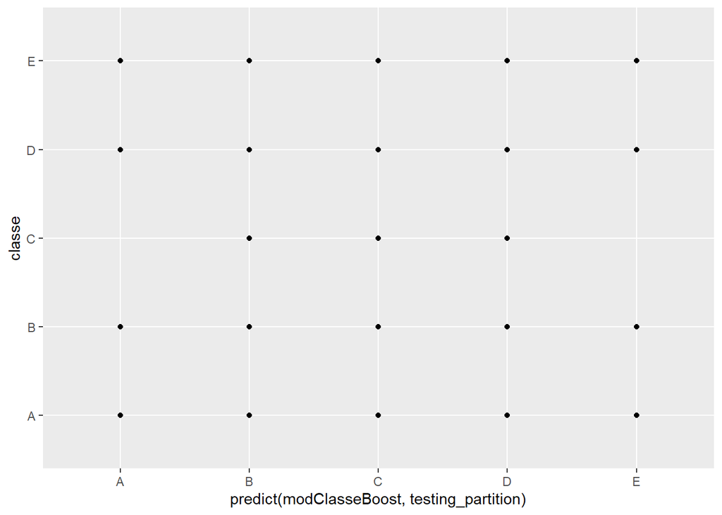

```r
#Predicting new values
predmodBoost <- predict(modClasseBoost, testing_partition)
#Ploting results
qplot(predict(modClasseBoost, testing_partition), classe, data = testing_partition)
```

```r
#Accuracy
confMatBoosting <- confusionMatrix(predict(modClasseBoost, testing_partition), testing_partition$classe)
confMatBoosting
```

```
## Confusion Matrix and Statistics
##
##           Reference
## Prediction    A    B    C    D    E
##          A 1648   44    0    2    3
##          B   15 1054   29    1   11
##          C    8   38  987   25    7
##          D    2    2   10  933   16
##          E    1    1    0    3 1045
##
## Overall Statistics
##
##                Accuracy : 0.963
##                  95% CI : (0.9578, 0.9676)
##     No Information Rate : 0.2845
##     P-Value [Acc > NIR] : < 2.2e-16
##
##                   Kappa : 0.9531
##
##  Mcnemar's Test P-Value : 2.598e-08
##
## Statistics by Class:
##
##                      Class: A Class: B Class: C Class: D Class: E
## Sensitivity            0.9845   0.9254   0.9620   0.9678   0.9658
## Specificity            0.9884   0.9882   0.9839   0.9939   0.9990
## Pos Pred Value         0.9711   0.9495   0.9268   0.9688   0.9952
## Neg Pred Value         0.9938   0.9822   0.9919   0.9937   0.9923
## Prevalence             0.2845   0.1935   0.1743   0.1638   0.1839
## Detection Rate         0.2800   0.1791   0.1677   0.1585   0.1776
## Detection Prevalence   0.2884   0.1886   0.1810   0.1636   0.1784
## Balanced Accuracy      0.9864   0.9568   0.9730   0.9809   0.9824
```

Boosting with trees also has very high accuracy; so out of sample error is low.

### Conclusion - Model Selection

The aproaches show that random forest and boosting trees are more accurate than prediction with trees.

Since random forest has a slightly better accuracy, this model will be chosen to be applied to testing dataset.

### Applying Random Forest to Testing Dataset

Since random forest is more accurate, it will be applied to predict the 20 different test cases using testing dataset.

```r
predict_testing <- predict(modClasseRF, newdata=testing)
predict_testing
```

```
##  [1] B A B A A E D B A A B C B A E E A B B B
## Levels: A B C D E
```